# Exploration of Financial Contributions to Presidential Campaigns in California

Vivek Pandey

December 7, 2018

# Abstract:

In 2016 United State presidential election Donald Trump J. became 45th president of US. There were many factors which contributed in winning US presidential election and Financial contribution from US contributors was one of the factor which impacted that election outcome.  
In this project, I am going to investigate the financial factor that could potentially contribute to the outcome of the 2016 presidential election campaign, and for this exploratory data analysis I chose California state data because I live here and second reason is that Donald Trump lost in California despite of winning US president election,. so I am interested in doing research demographics and geographical distribution of contributors/donors for each party and each candidate and find out the trends of the campaign, and at the end my research will be focused on two primarily rivals Donald Trump J. and Hillary Clinton.

For this research I got the financial data from [FEC site](https://classic.fec.gov/disclosurep/pnational.do). This dataset contains financial contribution transaction from 05-Nov-2013 to 31-Dec-2016, and using California dataset I will try to answer below questions:

1- Which candidate and party did receive the most support in California in terms of money and no of supporters. 2- What do these contributors do and how does contributors’ occupation and gender impact the contribution towards a particular candidate and a party and are there any pattern in that. 3- Where do these donations come from geographically? 4- Also I am interested in contribution pattern over course of election campaign and how it is varying when election was approaching.

```
## 'data.frame':    1304346 obs. of  17 variables:
##  $ cmte_id          : chr  "C00575795" "C00575795" "C00575795" "C00580100" ...
##  $ cand_id          : chr  "P00003392" "P00003392" "P00003392" "P80001571" ...
##  $ cand_nm          : chr  "Clinton, Hillary Rodham" "Clinton, Hillary Rodham" "Clinton, Hillary Rodham" "Trump, Donald J." ...
##  $ contbr_nm        : chr  "AULL, ANNE" "CARROLL, MARYJEAN" "GANDARA, DESIREE" "RODACY, JON" ...
##  $ contbr_city      : chr  "LARKSPUR" "CAMBRIA" "FONTANA" "LIVINGSTON" ...
##  $ contbr_st        : chr  "CA" "CA" "CA" "CA" ...
##  $ contbr_zip       : chr  "949391913" "934284638" "923371507" "95334" ...
##  $ contbr_employer  : chr  "N/A" "N/A" "N/A" "INFORMATION REQUESTED" ...
##  $ contbr_occupation: chr  "RETIRED" "RETIRED" "RETIRED" "INFORMATION REQUESTED" ...
##  $ contb_receipt_amt: num  50 200 5 48.3 40 ...
##  $ contb_receipt_dt : chr  "26-APR-16" "20-APR-16" "02-APR-16" "21-NOV-16" ...
##  $ receipt_desc     : chr  "" "" "" "" ...
##  $ memo_cd          : chr  "X" "X" "X" "X" ...
##  $ memo_text        : chr  "* HILLARY VICTORY FUND" "* HILLARY VICTORY FUND" "* HILLARY VICTORY FUND" "" ...
##  $ form_tp          : chr  "SA18" "SA18" "SA18" "SA18" ...
##  $ file_num         : int  1091718 1091718 1091718 1146165 1077404 1146165 1077404 1077404 1077404 1091718 ...
##  $ tran_id          : chr  "C4768722" "C4747242" "C4666603" "SA18.177204" ...
```

This dataset consists of 17 variables with 1304346 observations.

```
##     Min.  1st Qu.   Median     Mean  3rd Qu.     Max.
## -10500.0     15.0     27.0    116.2     88.0  10800.0
```

After looking at summary of contribution amount received we found that min amount is negative 10500 which can not be less than 0. Also mean amount is 116.2 which is because of some of people has contributed a way more money than average contribution amount which is impacting the mean contributing amount. Hence median 27 is better option to find out average contributing amount. Since we can not have contributing amount less than 0 hence I have decided to remove those observations from the dataset.

```
##     Min.  1st Qu.   Median     Mean  3rd Qu.     Max.
##     0.01    15.00    27.00   123.15    99.00 10800.00
```

After removing negative contributing amount data we found that median is still $27 which is giving accurate average contribution amount, also as per summary 75% contributors contributed upto $99.

# Data Preparation:

For this dataset exploratory analysis I would require to know gender of each contributors which I can derive from the first name of the contributor using ‘gender’ package, moreover I would also need to know which party does each candidate belong to, in addition to this for geographical analysis I would need to know geographical location (latitude and longitude), hence these three new dimensions/variables are require for this analysis.

After adding six new variables first_nm, last_nm,gender,party,longitude and latitude now we have 23 variables in the updated dataset with 1237421 observations.

# Univariate Plots Section

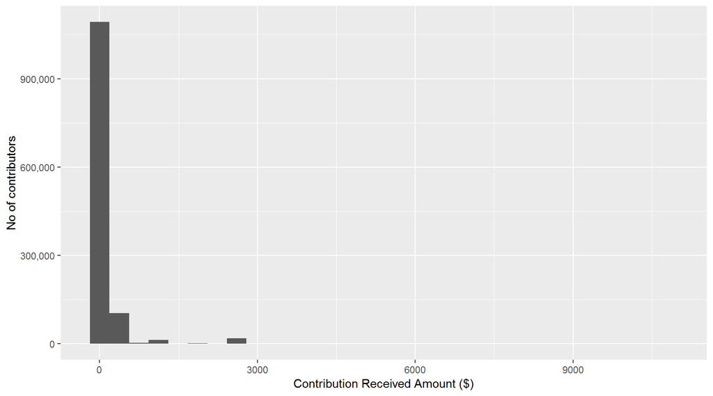

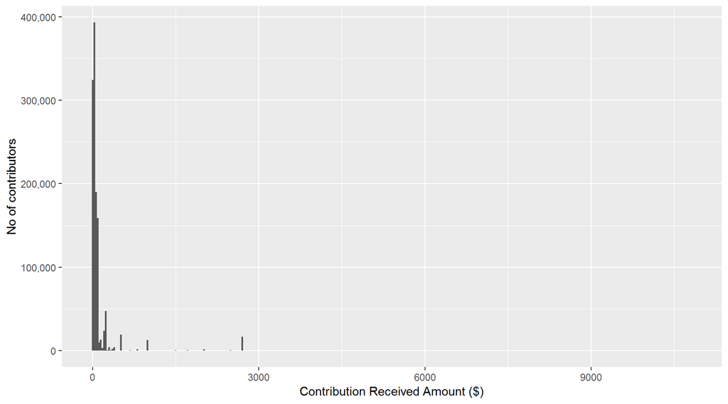

I have analyzed the distribution of contrubution amount and as per the above two graphs contribution amount is right skewed, so we can apply square root transformation to better visualize this distribution.

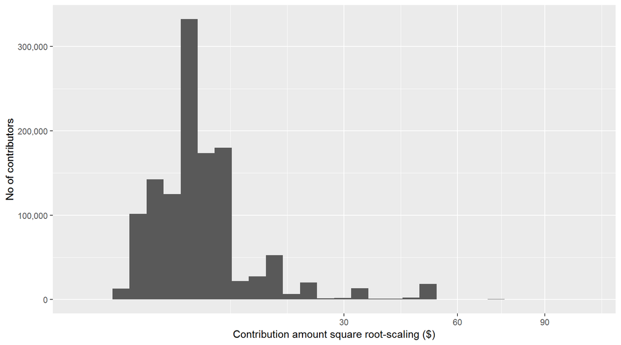

After square root transformation we can say that most of the contributers are contributing less amount of money which is around less than $100, however some are contributing large ampount of money.

```
## # A tibble: 2 x 2
##   `CA_FEC1$gender`  count
##   <chr>             <int>
## 1 female           663726
## 2 male             573695
```

The above gender summary tells us that more no of females were contributing in financial campaign.

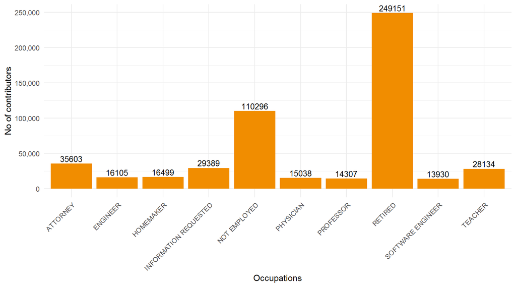

As there are so many occupations reported and in order to focus on more common occupations I have selected only Top 10 occupations that contributed to US presidential candidate. As per the above graph we can see that retired people has contributed most in US presidential campaign and followed by “Not Employed”" who can be freelancers, after that significant no of people from “Attorney”, “INFORMATION REQUESTED” and “TEACHER” professions are actively contributing. However it is strange that retired and not employed people have contributed most instead of emmployed and high paid professionals.

# Univariate Analysis

### What is the structure of your dataset?

There are 1304346 financial contribution transactions for different president candidates in the dataset with 17 features such as cand_nm,contbr_nm,contbr_city, contbr_zip, contbr_occupation etc. Other observations: - Some contribution amounts were negative which we have removed from the dataset. - Median contribution amount is $27. - As per summary 75% contributors contributed upto $99. - More no of females were contributing in US presidential financial campaign. - Most no of people who contributed are retired peole.

### What is/are the main feature(s) of interest in your dataset?

The main feature is contb_receipt_amt and I want to do analysis on contb_receipt_amt distribution using it’s summary with other variables to find out the patterns if any.

### What other features in the dataset do you think will help support your investigation into your feature(s) of interest?

I think that cand_nm,contbr_nm,contbr_city, contbr_zip, contbr_occupation and contb_receipt_dt columns can help us to understand the patterns in 2016 US presidential election campaign.

### Did you create any new variables from existing variables in the dataset?

I have created six new variables first_nm, last_nm, gender, party, longitude and latitude to find out the most relevant factors which impacted most in 2016 US presidential election.

### Of the features you investigated, were there any unusual distributions? Did you perform any operations on the data to tidy, adjust, or change the form of the data? If so, why did you do this?

I found some negative contributing amount which was unusal hence I have removed those transactions from the final data which I have used for analysis. I square root transformed the right skewed contribution amount, and after that transformation we were able to better visualize amount distribution and it seems most of the contributers are contributing less amount of money which is around less than $100.

# Bivariate Plots Section

```
## # A tibble: 2 x 2
##   party      Total_Amount
##   <chr>             <dbl>
## 1 democratic   111129167.
## 2 republican    40369327.
```

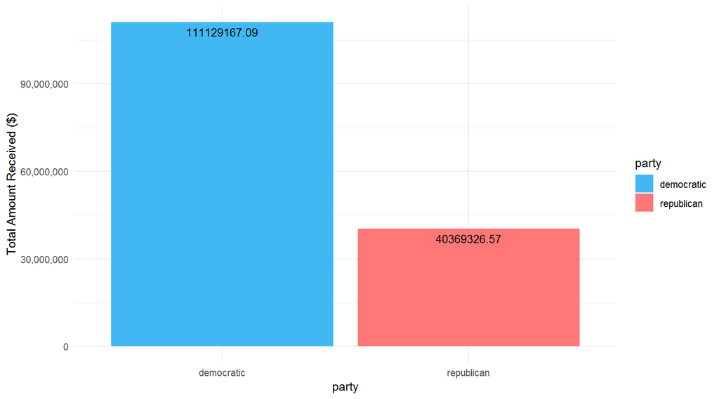

As per the above graph of total amount received by party tells us that democratic party received almost 3 times more money than republican party, and democratic party seems most favourite in California for 2016 US president election. Next I will try to find out top one candidate from each party who received maximum contribution.

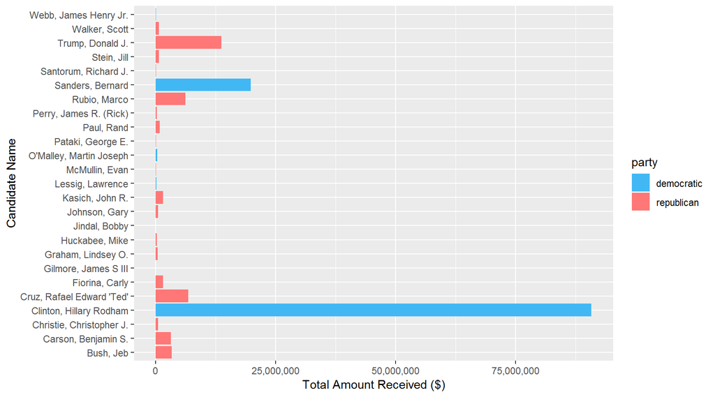

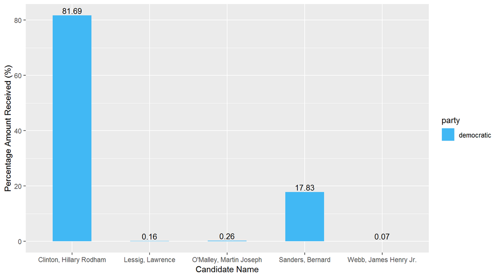

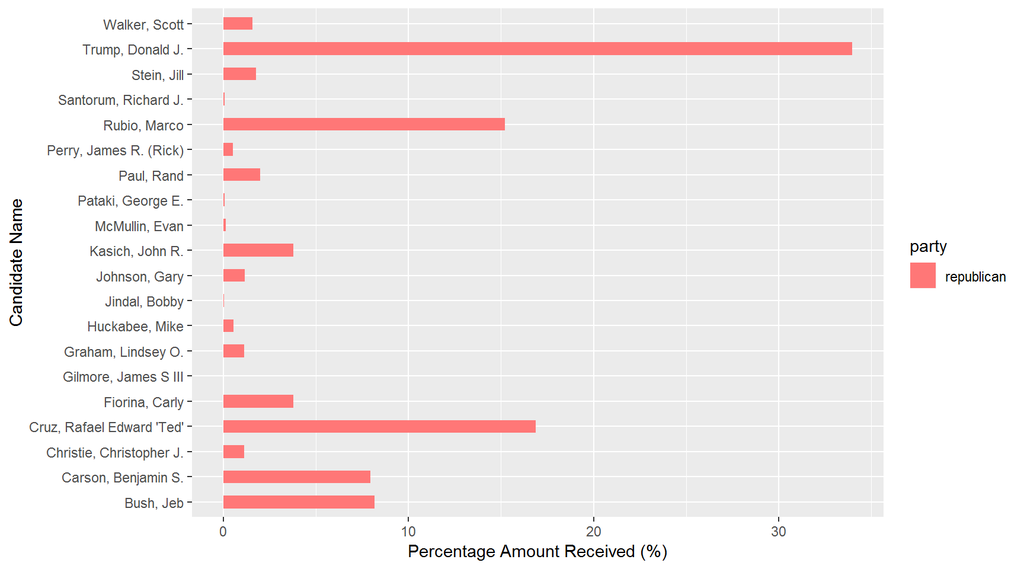

As per the above graphs of contribution received by individual candidates of each party we can say that majority of contribution is concentrated on top contenders within each party. For Democratic party 99% of contributing amount received in California goes to Hillary Clinton and Bernard Sanders, and of which 81.69% goes to Hillary Clinton. For Republican party 66% amount goes to top three candidates Donald Trump, Rafael Ted Cruz and Rubio Marco, and of which 34% goes to Donald Trump, and 24% goes to other four candidates and rest of 12 candidates received 10% contributing amount. As I wanted to find out top 5 candidates who received maximum contributing amount so from the above analysis two candidates from Democratic party are Hillary Clinton ,Bernard Sanders and three candidates from Republican party are Donald Trump, Rafael Ted Cruz and Rubio Marco. I will take these five candidates for time series analysis to find out the pattern if California people were more inclined towards any party or any particular candidate.

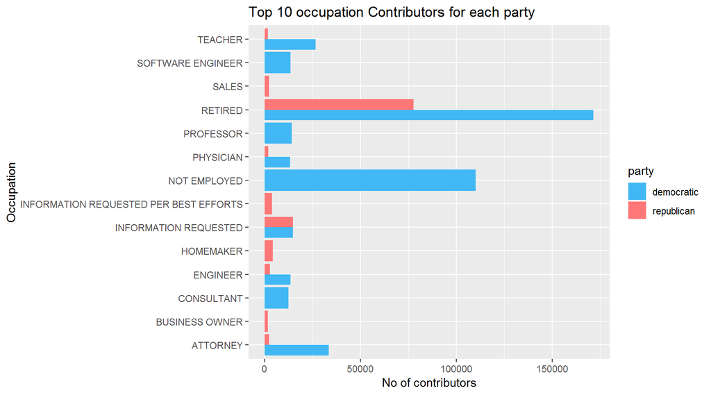

# Contribution by Gender:

```
## # A tibble: 4 x 3
## # Groups:   gender [?]
##   gender party      Total_Amount
##   <chr>  <chr>             <dbl>
## 1 female democratic    57458685.
## 2 female republican    13311019.
## 3 male   democratic    53670482.
## 4 male   republican    27058307.
```

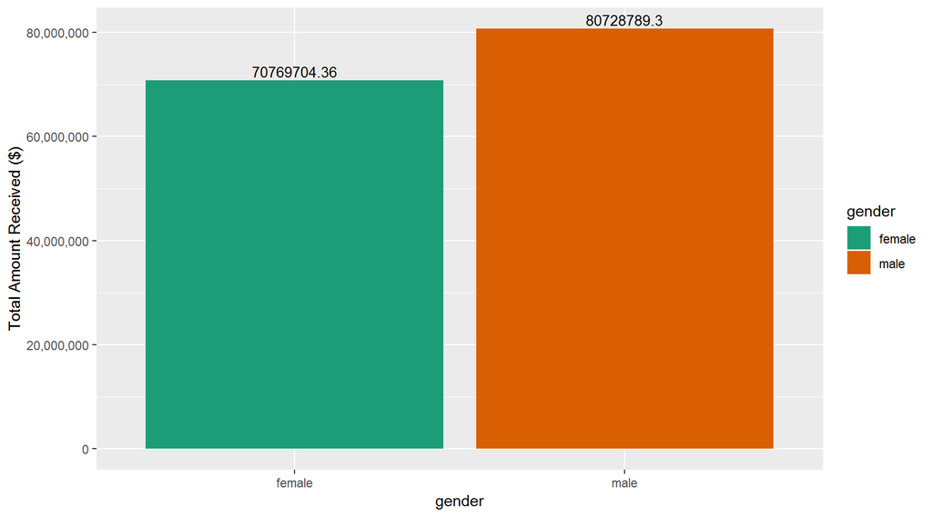

As gender is also very important variable to analyze to find out whether male or female was contributing more,and as per above contributing amount received by gender graph shows that male has contributed more money than female. However Hillary Clinton was one of the very popular female candidate for US 2016 election, so I am very much interested to do further analysis to find out if female has contributed more to Hillary clinton.

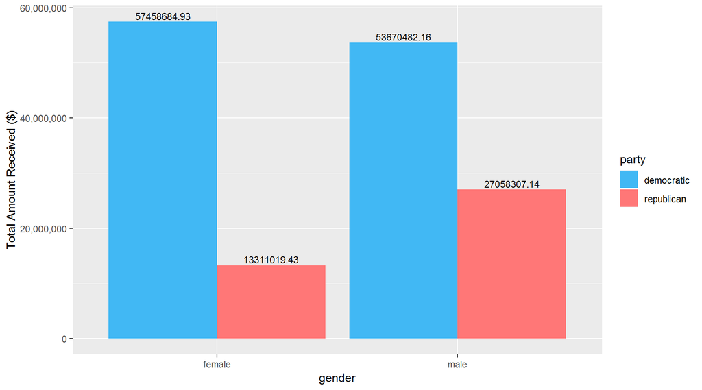

As per the above graph we can say that female has contributed 4 times more to democratic party than republican and this influence can be because of female president candidate Hillary clinton, so I want to investigate further by candidate and party.

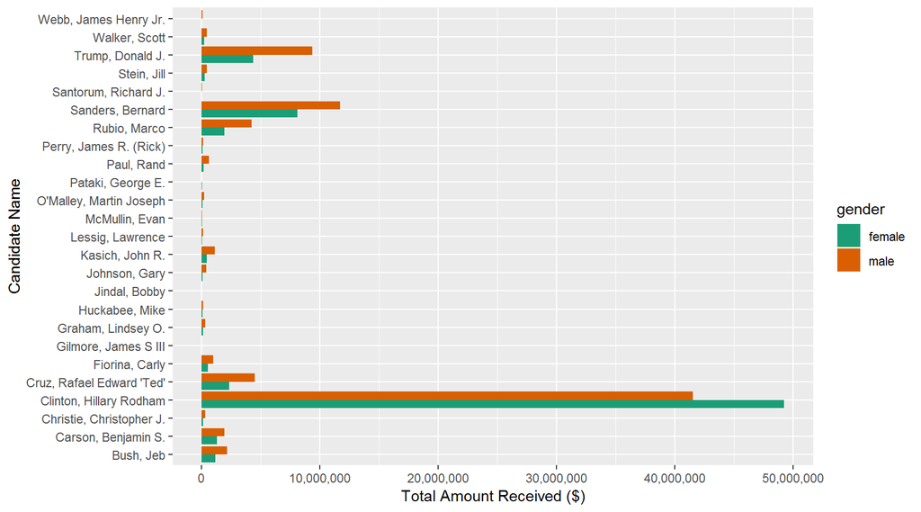

After looking at contribution by gender and candidate we can say that female has mainly contributed to Hillary clinton.

# Bivariate Analysis

### Talk about some of the relationships you observed in this part of the investigation. How did the feature(s) of interest vary with other features in the dataset?

Most of the total contribution in California went to the Democratic party which is almost 3 times more than republican party. - Within each party, the majority of contributions were received by top contenders. - For Democratic party 99% of contributing amount received in California goes to Hillary Clinton and Bernard Sanders, and of which 81.69% goes to Hillary Clinton. - In California majority of the contributions from female contributors went to Democratic party and female candidate. - Most of these contributions from female were made to Hillary Clinton.

### Did you observe any interesting relationships between the other features (not the main feature(s) of interest)?

Majority of Retired people contributed to Democratic party however surprisingly all Not employed people who belongs to second highest contributor’s profession had contributed to Democratic party only.

### What was the strongest relationship you found?

Male had higher contributing amount than female.

# Multivariate Plots Section

### Contribution by Geographical Location:

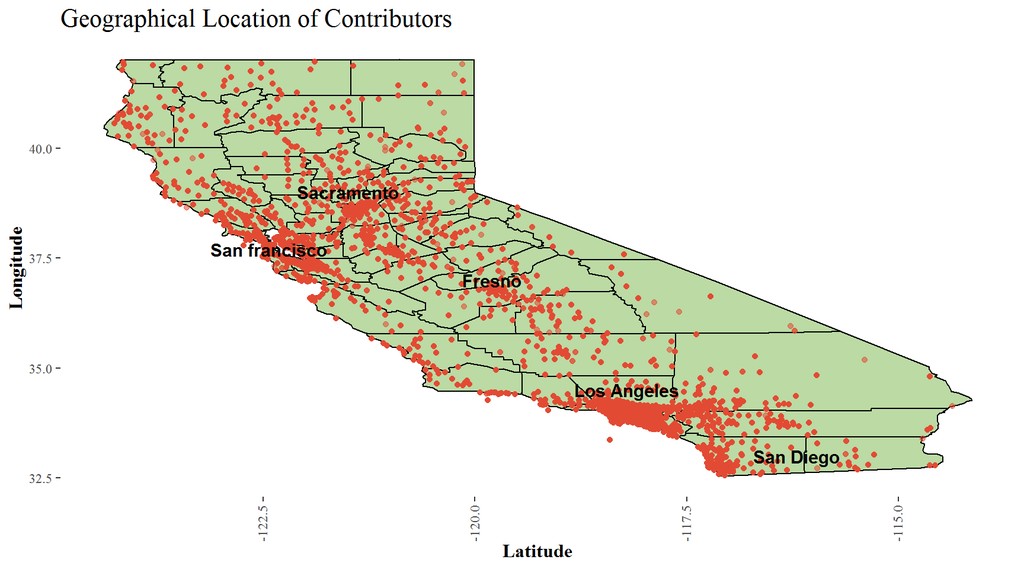

As per the above graph we can say that majority of contribution were coming from major cities of California which are San Francisco, Los Angeles, Sacramento and San Diego.

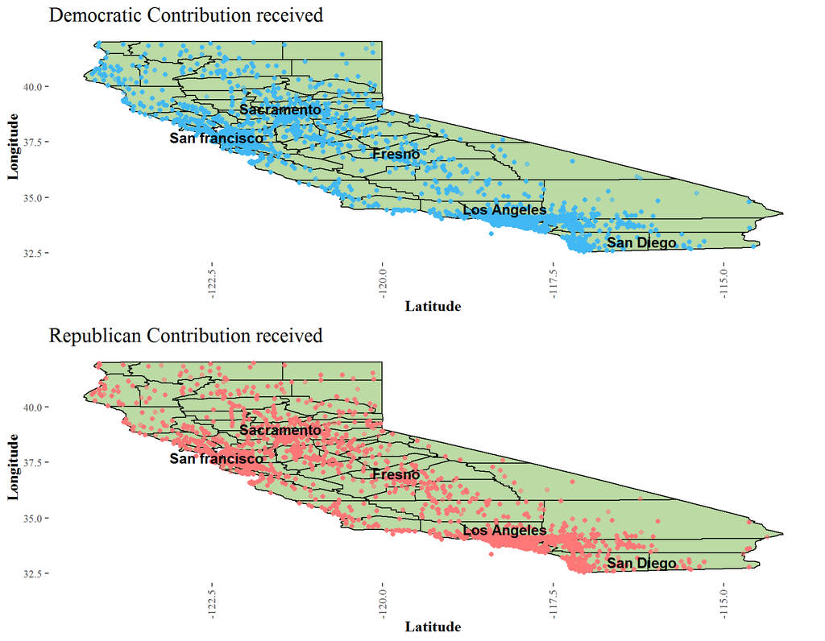

As per the previous analysis democratic party received more contribution in California however I wanted to analyze further the distribution of contributing amount across California whether all across California people were contributing more to Democratic party, however as per the above graph we can not conclude that Democratic party received more contribution all across California and it seems both parties received majority of their contribution from major cities of California.

### Contribution by Time Series:

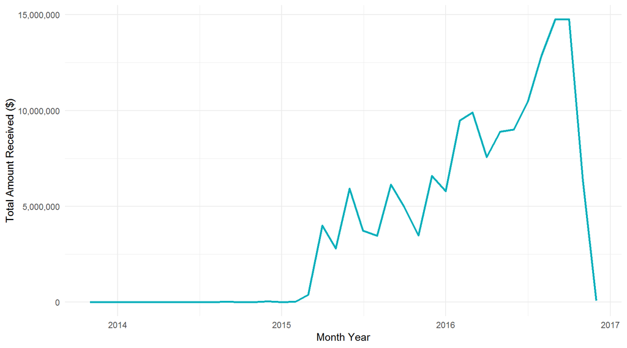

As per the above time series graph of contribution amount over course of US presidential financial campaign we can say that financial contribution in california was keep increasing and it was very high when election was approaching.  
Also I will be doing this time series analysis on top 5 candidates and will analysis how it varies during the election campaign.

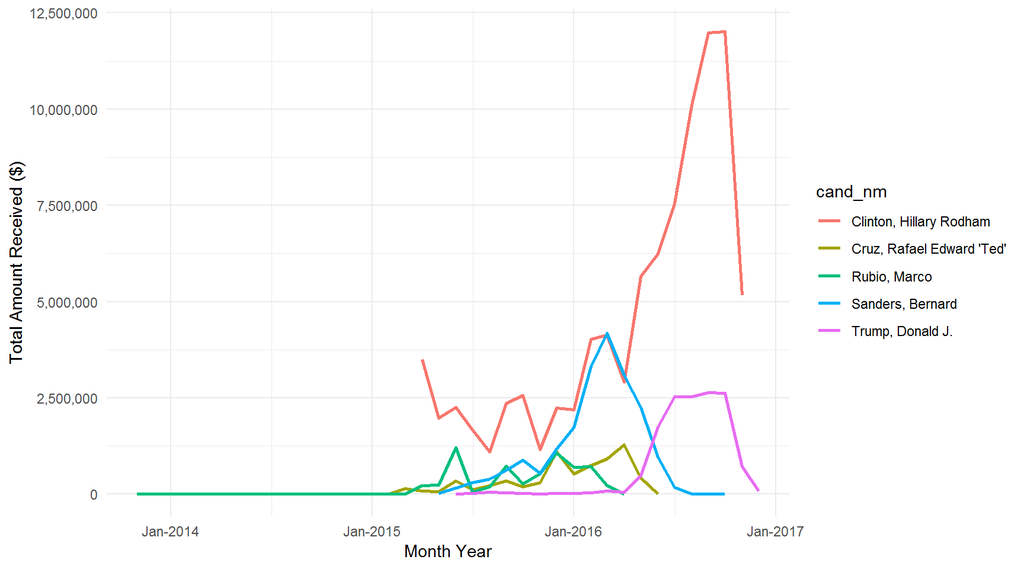

As per the above time series graph of contribution received by top 5 candidates in California we can say that from 2014 the start of the US presidential financial campaign till eight months before the election Bernard Sanders’s contribution amount received was appraching to Hillary Clinton’s contribution amount and other candidates were also getting decent contribution from California people and surprisingly Trump received least amount among these five candidates. However, in the last 8 months of campaign only Hillary clinton was getting a beyond financial suport from California people and one more very surprise thing was that Trump was started getting very significant amount of contribution in california which was giving positive sentiments towards Trump though Hillary Clinton was most favorite.

# Multivariate Analysis

### Were there any interesting or surprising interactions between features?

For a certain period of time, Bernard Sanders received more donations and gained more popularity than Hillary Clinton.

# Final Plots and Summary

### Most Contribution went to a few candidates

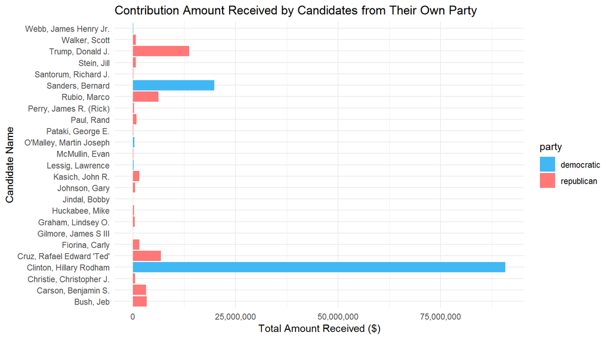

### Female contributed less than male however female contributed more to female candidate:

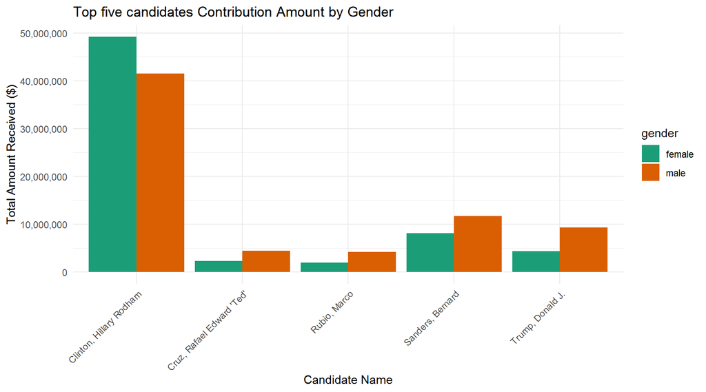

In California male has contributed more money than female, and as per previous analysis female has contributed more to democratic party and from the above graph of top five candidates we can say that female contributors dominantly contributed to Hillary Clinton, and it gives us clear pattern that female are highly inclined to contribute to female candidate and on the other hand male are contributing more to male candidates.

### Contribution by Occupation

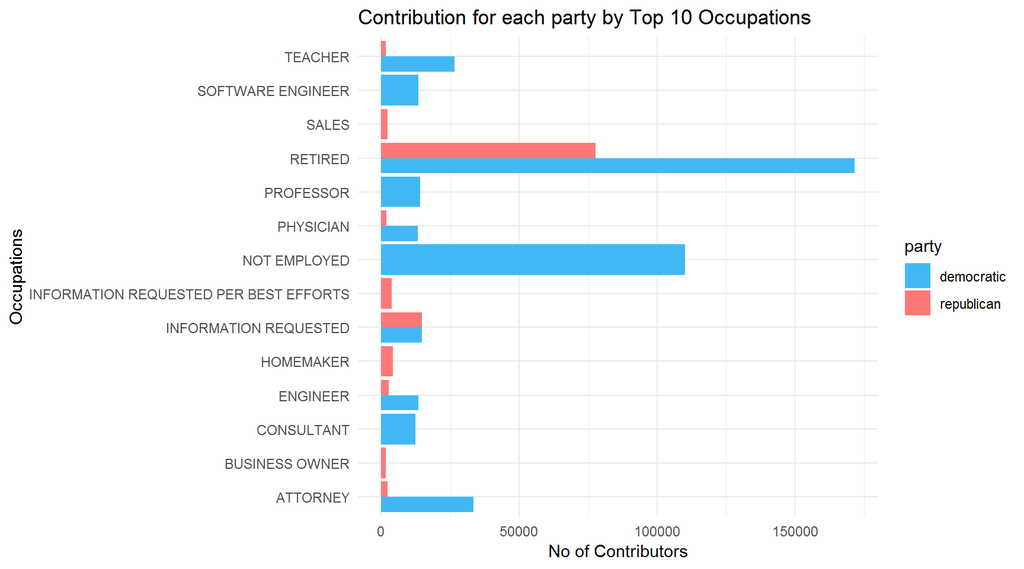

# Reflection

While analyzing this dataset I came across multiple challenges and issues. - The original dataset didn’t has gender information and in order to analyze contribution by gender I have used ‘gender’ R package to derive gender from the first name of contributors. - For geographical analysis longitude and latitude were require however the original dataset had only zipcode of contributor, so I had used ‘zipcode’ R package to derive these two attributes from zipcode, and I have used ggmap to analyze contributors by location. - I was not thoroughly aware of US presidential election process, so before doing any analysis I had to spent some time to acquire this fundamental knowledge so that my analysis should not be biased.

### Conclusion: After analyzing California financial contribution data I came across many interesting findings and patterns.

- Democratic party received more contribution than republican party.
- The Majority of contribution was received by top contenders.
- Female contributors contributed more to Democratic party and female candidate.
- Female made maximum contribution to Hillary Clinton.
- Retired people contributed more to Democratic party however surprisingly Not employed people had contributed to only Democratic party.
- Majority of contribution came from top five major cities of California.
- For a certain period of time, Bernard Sanders received more contribution and gained more popularity than Hillary Clinton.

### Did you observe any interesting relationships between the other features (not the main feature(s) of interest)?

Majority of Retired people contributed to Democratic party however surprisingly all Not employed people who belongs to second highest contributor’s profession had contributed to Democratic party only.

### Future Work:

I analyzed 2016 US presidential financial campaign data for California state and came across some popular president contenders and their finding in California however it would be very interesting to analyze other states financial campaign data as well as nationwide data so that we can predict accurately which candidate and party had very good chance of winning the president election based on financial campaign across US.